# ESM 244 Assignment 2

Camila Bobroff

2/14/2019

### Task 1: Cetaceans in Captivity

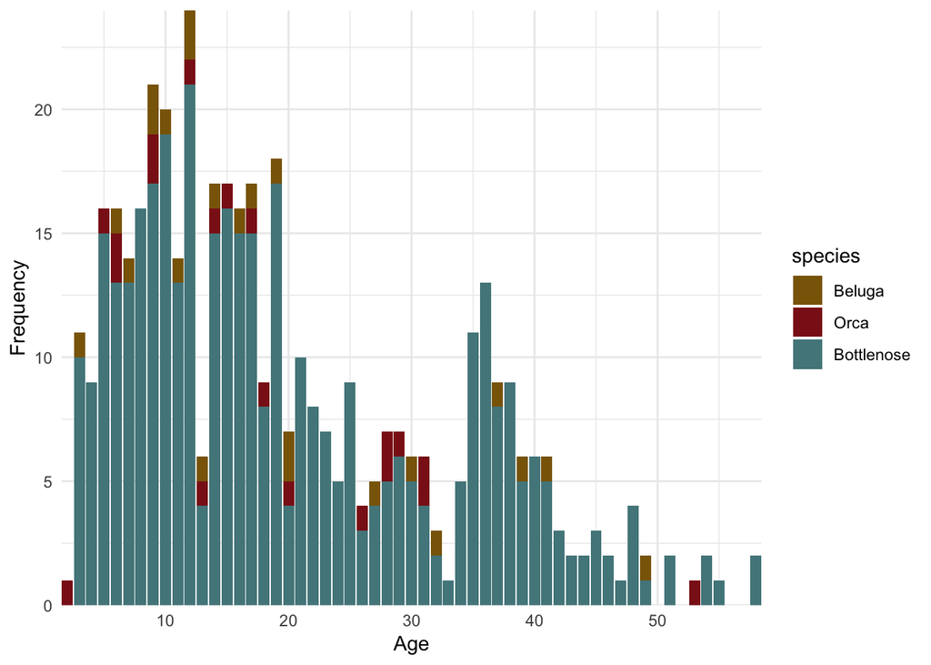

```r
captive_top3 <- captive_cetacean %>%
  filter(status == "Alive") %>%
  count(species) %>%
  top_n(3)

captive_top3 <- captive_cetacean %>%
  filter(species == "Bottlenose" |
           species == "Killer Whale; Orca" |
           species == "Beluga",
         status == "Alive") %>%
  select(species, name, sex, birthYear, originLocation, transfers, currently) %>%
  mutate(age = 2019-as.numeric(birthYear)) %>%
  arrange(desc(species))

captive_top3$species <- fct_relevel(captive_top3$species, "Beluga", "Killer Whale; Orca", "Bottlenose")

captive_ages <- captive_top3 %>%
  ggplot(aes(x = age)) +
  geom_bar(aes(fill = species), levels = c("Bottlenose", "Killer Whale; Orca", "Beluga")) +
  scale_fill_manual(values = c("darkgoldenrod4", "firebrick4", "cadetblue4"), labels = c("Beluga", "Orca", "Bottlenose")) +
  scale_x_continuous(expand = c(0,0)) +
  scale_y_continuous(expand = c(0,0)) +
  theme_minimal() +
  labs(x = "Age", y = "Frequency")

captive_ages
```

### Task 2: Parameter Estimation – Wild Fish Catch

#### a) Exploratory graph of wild catch over time

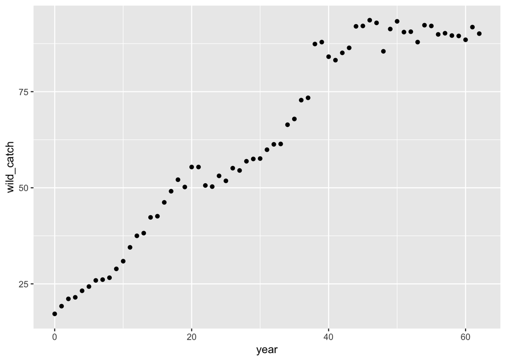

#### b) The trend in the exploratory graph of wild catch over time is logistic.

$N_t = \left(\frac{A}{1 + \beta e^{-rt}}\right)$

**Initial Estimates**

- $A = 85$ million tons
- If $N_0$ is estimated at $20$ million tons, $\beta$:  
  $\beta = \frac{(K - N_0)}{N_0} = \frac{(85-20)}{20} = 3.25$
- $r = .025$

#### c) Nonlinear least squares parameters

- $A = 100$ million tons
- $\beta = 4.32$
- $r = .07$ million tons of wild fish caught per year (growth rate estimate when exponential growth dominates)

#### d) Final graph of original data and model output

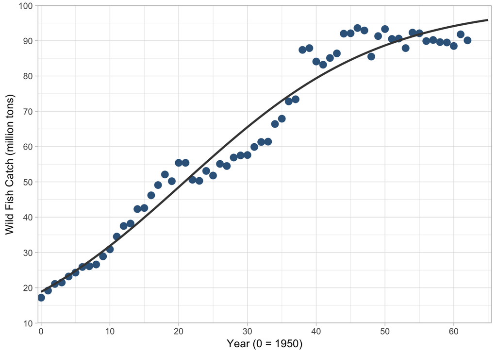

```r
# Create a new sequence of time values (time_seq)
time_seq <- seq(0,65, length = 500)

# Plug that new sequence into my model with the parameters A, B and r that were found:
fish_pred <- A/(1 + B * exp(-r*time_seq)) # Predictions based on time_seq
# Bind with the time_seq data:
pred_df <- data.frame(time_seq, fish_pred)

# Graph with the original data and model predictions:
ggplot(fish_catch, aes(x = year, y = wild_catch)) +
  geom_point(color = "steelblue4", size = 3) +
  geom_line(data = pred_df, aes(x = time_seq, y = fish_pred), color = "gray26", size = 1) +
  labs(x = "Year (0 = 1950)", y = "Wild Fish Catch (million tons)") +
  scale_x_continuous(expand = c(0,0.5), limits = c(0, 65), breaks = seq(0,65, by = 10)) +
  scale_y_continuous(expand = c(0,0), limits = c(10,100), breaks = seq(0,100, by = 10)) +
  theme_light()
```

### Task 3: Bootstrapped Confidence Interval for Proportions

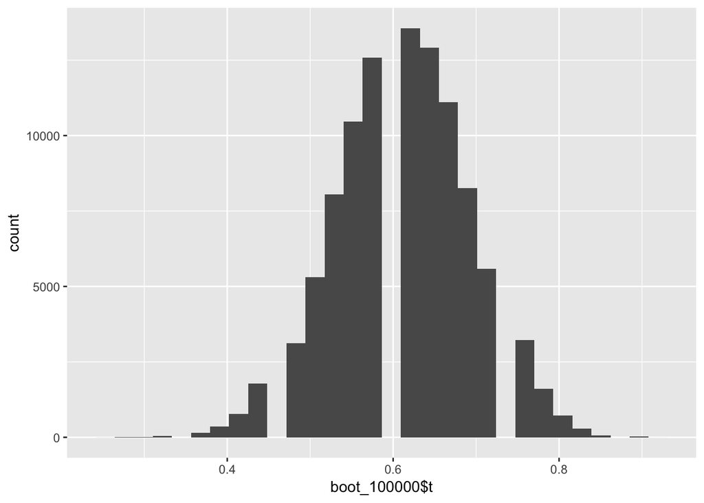

```r
# Find confidence interval for the proportion of nonbinary/genderqueer students experiencing exclusionary, hostile, or intimidating conduct at UCSB.N = 36, 22 identified as having personally experienced exclusionary, hostile, or intimidating conduct at UCSB.

# create a vector of proportions to use for bootstrapping
# 1 = experience exclusionary conduct 0= did not experience exclusionary conduct
exclusionary_conduct <- c(1,1,1,1,1,1,1,1,1,1,1,1,1,1,1,1,1,1,1,1,1,1,0,0,0,0,0,0,0,0,0,0,0,0,0,0)

exclusion_function <- function(x,i) {mean(x[i])} # i accounts for the different bootstrap samples, x is the bootstrap sample

set.seed(10) # keeps the outcome of the next line of code the same
boot_100000 <- boot(exclusionary_conduct, exclusion_function, R = 100000)

ggplot() +
  aes(boot_100000$t) +
  geom_histogram()
```

```r
# Calculate the confidence interval using the boot.ci() function in the boot package
boot.ci(boot_100000, conf = 0.95)
```

```
## BOOTSTRAP CONFIDENCE INTERVAL CALCULATIONS
## Based on 100000 bootstrap replicates
##
## CALL :
## boot.ci(boot.out = boot_100000, conf = 0.95)
##
## Intervals :
## Level      Normal              Basic
## 95%   ( 0.4517,  0.7701 )   ( 0.4444,  0.7778 )
##
## Level     Percentile            BCa
## 95%   ( 0.4444,  0.7778 )   ( 0.4167,  0.7222 )
## Calculations and Intervals on Original Scale
```

The proportion of nonbinary and gender-queer students who experience exclusionary, hostile, or intimidating conduct is 61% (n = 36), with a bootstrapped 95% confidence interval of [44, 78] percent (n = 100,000 bootstrap samples).  
Source: 2014 UCSB Campus Climate Project Final Report, prepared by Rankin & Associates Consulting: http://campusclimate.ucop.edu/_common/files/pdf-climate/ucsb-full-report.pdf

### Task 4: Watch 3 RStudio::conf talks

The next million R users - Carl Howe  
- RStudio’s Mission: Equip everyone, regardless of means, to participate in a global economy that rewards data literacy. RStudio Education’s mission: Train the next million R users.  
- Males made up 75% of respondents of the survey… not doing as well as anticipated.  
- Inspiring to see that the mean age that folks started using R was age 30! I’m not too late :)  
- What keeps people from using R : Error messages (R users) and language syntax & getting started (Non-Users, small sample)  
- RStudio primers to learn R on your own!  
Question: How do you plan to increase the diversity of R users, particularly women and people of color?

The resilient R champion - Tonya Filz  
- Barriers faced by R Champion: Open source mentality (why trust open source tools), funding, IT support, internal political pressure.  
- To overcome funding barriers, create demand for data products/assets using Open Source tools. Really show your organization what R can do (i.e. Shiny). Communicate all the possibilities!  
- Ask lots of questions to figure out what the organization really needs and consider whether it can be accomplished using R open source tools. More tools is not always bad.  
Question: What are some examples of organizations that have successfully started using R? Any public sector or non-profit organizations?

Teaching R using inclusive pedagogy: Practices and lessons learned from over 700 Carpentries workshops - Tracy Teal  
- “Data becomes a tool of profound social change or a weapon of political warfare – depending on whose hands it is in” Yeshimabeit Milner, Executive Director and Founder of Data for Black Lives. Data is power and the questions asked will depend on who is asking them.  
- The Carpentries is an open, global community teaching researchers the skills to turn data into knowledge.  
- Growth mindset with inclusive pedagogy - confidence, focus on effort and incremental learning, not outcomes. Seeing mistakes as opportunities for learning, safe space for continues learning.  
Question: What are some changes that The Carpentries will be making in order to reach more broad and diverse communities?